# numpy Class_Project_1a_Stickeralbum_Solution

# The Sticker Album Challange

## Solution with Python Standard Library

## 1. Getting startet...one simulation

Your Sticker Album has a capacity of 600 unique Stickers (consecutively numbered from 1 to 600) and your budget allows you to buy 800 stickers, hoping to complete the album with max 200 duplicates...(naive start of the game...)

We assign

- **600** to the variable **album_capacity**
- **800** to the variable **purchased_stickers**

```python
album_capacity = 600
purchased_stickers = 800
```

Before we can simulate the random purchase of stickers, we have to **import the "random" module** first...

```python
import random
```

Now let´s simulate the random **purchase of one sticker**. Use **random.randint** and keep in mind that stickers are consecutively numbered from **1 to 600**.

```python
random.randint(1,600)
```

```
322
```

Alright, that works. Let´s now simulate the random **purchase of 800 stickers** by using a **for loop** (using **range(purchased_stickers)**).  
Before we start looping, we need to

- buy our Sticker album by **creating an empty list** called **album**
- set **random.seed** to **123** in order to create "pseudo-random" numbers which enables you to exactly replicate my simulation process.

Once we have finished these two steps, we can

- use a **for loop**
- **name** each randomly created number **sticker**
- and **append** each sticker to our **album**.

```python
album = []
random.seed(123)

for i in range(purchased_stickers):
    sticker = random.randint(1,600)
    album.append(sticker)
```

Let´s inspect our album by **printing** it and verify that the total number of stickers is indeed 800 (**len(album)**).

```python
album
```

```
[54,
 275,
 90,
 418,
 273,
 111,
 40,
 389,
 550,
 576,
 341,
 349,
 54,
 164,
 139,
 346,
 575,
 342,
 252,
 168,
 2,
 447,
 90,
 387,
 72,
 7,
 324,
 460,
 105,
 45,
 95,
 146,
 130,
 22,
 299,
 441,
 588,
 489,
 272,
 481,
```

[output cut: 745 more lines]

```
 85,
 67,
 433,
 460,
 448,
 459,
 42,
 425,
 53,
 97,
 307,
 520,
 403,
 386,
 341]
```

```python
len(album)
```

```
800
```

Do you think we have a complete album and our naive approach is working? Let´s check how many **unique Stickers** and how many **duplicates** we have. We should at least have 200 duplicates that we cannot paste into the album.  
Use **set(list)** to transform the list object album into a **set object** and we get all unique stickers (assign the variable **unique**).

```python
unique = set(album)
unique
```

```
{1,
 2,
 3,
 4,
 5,
 6,
 7,
 9,
 10,
 11,
 12,
 13,
 14,
 15,
 17,
 18,
 21,
 22,
 24,
 25,
 27,
 28,
 29,
 30,
 31,
 32,
 33,
 34,
 35,
 37,
 38,
 39,
 40,
 41,
 42,
 43,
 44,
 45,
 46,
 47,
```

[output cut: 396 more lines]

```
 576,
 577,
 579,
 583,
 584,
 586,
 587,
 588,
 589,
 592,
 593,
 595,
 598,
 599,
 600}
```

Use the **len() function** to determine the number of unique stickers in our album.

```python
len(unique)
```

```
451
```

Ok, we have **451 unique stickers**. Our album is 75% complete.

Let´s make a crosscheck and get all duplicates by

- Creating a copy (**list.copy()**) of album and assign the variable **duplicates**.
- remove from duplicates all elements of unique (**list.remove()**)

```python
duplicates = album.copy()
for i in unique:
    duplicates.remove(i)
```

Print duplicates and determine the **amount (len()) of duplicates**. Should be **349**.

```python
len(duplicates)
```

```
349
```

This works. Now let us focus on our task to write code that reflects reality. We can only add/paste a sticker to our album, if it is not already in our album. Therefore we should **introduce an if statement** that is checking **if** each randomly created **sticker** is already **in** our **album**.

- If the sticker is already in our album, we are doing nothing (**pass**),
- otherwise (**else**) we **append the sticker to our album**.

**Copy** the Code a few lines above and **include the if statement** and then run the code again.

```python
album = []
random.seed(123)

for i in range(purchased_stickers):
    sticker = (random.randint(1,600))
    if sticker in album:
        pass
    else:
        album.append(sticker)
```

Perfect, let´s again inspect our album...How many **unique stickers** do we have?

```python
album
```

```
[54,
 275,
 90,
 418,
 273,
 111,
 40,
 389,
 550,
 576,
 341,
 349,
 164,
 139,
 346,
 575,
 342,
 252,
 168,
 2,
 447,
 387,
 72,
 7,
 324,
 460,
 105,
 45,
 95,
 146,
 130,
 22,
 299,
 441,
 588,
 489,
 272,
 481,
 38,
 313,
```

[output cut: 396 more lines]

```
 355,
 121,
 132,
 410,
 337,
 501,
 120,
 522,
 201,
 448,
 459,
 97,
 307,
 520,
 403]
```

```python
len(album)
```

```
451
```

Since we used the same random.seed parameter (123) we end up with the same result as before, **451 unique stickers**. This is disappointing as we require further 149 stickers to complete our album.  
Ok this was one simulation and maybe we had just bad luck... Let´s simulate this process many times (**many simulations**) and get many data points instead of only one data point. The resulting **probability distribution of all simulations** will give us more information about what we can expect.

## 2. Getting probabilistic...with many simulations

Allright let´s start smoothly and set the number of simulations (**sims**) to **10**.

```python
sims = 10
```

**Copy** the code block from above and **add at the very top**:

- an **empty list called results** where you can store the result of each simulation (length of each album)
- start another (outer) **for loop (range(sims))** to make 10 simulations/albums.

Next:

- Calculate and assign the **length** of each album **(len(album))**
- At the very bottom of the outer for loop, **append** the length of each album to the list **results**
- mind the **indents**!

```python
results =[]
random.seed(123)
for m in range(sims):
    album = []
    #random.seed(123)
    for i in range(purchased_stickers):
        sticker = (random.randint(1,600))
        if sticker in album:
            pass
        else:
            album.append(sticker)
    length = len(album)
    results.append(length)
```

Let´s inspect the results... Do you notice anything strange?

```python
results
```

```
[451, 446, 446, 444, 451, 435, 450, 436, 441, 447]
```

OK now we get **different results** and it looks like it´s not really getting better than 451!

Let´s further **increase simulations to 1000** to further reduce the impact of randomness (random noise). This is important when we later calculate statistics like mean, median, etc.  
Let´s continue. Copy the above code block and add **sims = 1000** at the very top and run the code.

```python
sims = 1000
results =[]
random.seed(123)
for m in range(sims):
    album = []
    for i in range(purchased_stickers):
        sticker = (random.randint(1,600))
        if sticker in album:
            pass
        else:
            album.append(sticker)
    length = len(album)
    results.append(length)
```

Make a sanity check and call **len(results)**. This should be **1000**!

```python
len(results)
```

```
1000
```

## 3. Analyzing results and calculating statistics

Perfect! Now it´s time to inspect our results in a more detailed way. Let´s calculate

- the Minimum using **min()** --> assign **Min**
- the Maximum using **max()** --> assign **Max**
- the Mean using **sum()/len()** --> assign **Mean**
- the Median using **def Median()** --> assign **Median**

```python
Min = min(results)
Min
```

```
418
```

```python
Max = max(results)
Max
```

```
471
```

```python
Mean = sum(results)/len(results)
Mean
```

```
442.44
```

```python
def Med(lst):
    n = len(lst)
    if n < 1:
            return None
    if n % 2 == 1:
            return sorted(lst)[n//2]
    else:
            return sum(sorted(lst)[n//2-1:n//2+1])/2.0
Median = Med(results)
Median
```

```
443.0
```

On average we can expect approx. **442 unique** stickers. But what could be more intuitive than **visualizing** our results to have a better understanding of the **probability distribution** of results???  
Let´s first

- **import matplotlib.pyplot as plt**.
- we require **%matplotlib inline**
- and we set style to **"seaborn"** (**plt.style.use()**)

```python
import matplotlib.pyplot as plt
%matplotlib inline
plt.style.use("seaborn")
```

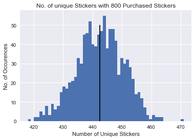

```python
plt.hist(results, bins = (Max-Min+1), density = False)
plt.vlines(Mean, 0, 50)
plt.xlabel("Number of Unique Stickers")
plt.ylabel("No. of Occurences")
plt.title("No. of unique Stickers with 800 Purchased Stickers")
plt.show()
```

## 4. Automation by writing a Function

We can be proud of our project so far, but what if we want to change

- the **album_capacity**
- the number of **purchased_stickers**
- the number of simulations (**sims**) we want to perform

in order to perform **more complex analysis** and **optimizations** to solve more advanced problems?

We should **automate** our project by **writing a function**!

Let´s define (**def**) a function called **StickerAlbum()** with the following **parameters** and **default values** inside the parentheses:

- **album_capacity** = 600
- **purchased_stickers** = 800
- **sims** = 1000
- **seed** = 123

This is called the **Function Header**.

Add a return statement: **return** the string **"This is the result of Stickeralbum()"** in order to have a working function in the first place.

```python
def StickerAlbum(album_capacity = 600, purchased_stickers = 800, sims = 1000, seed = 123):
    return "This is the result of StickerAlbum()"
```

**Call** the function with **default parameters** (simply **Stickeralbum()**) to check if everything is working so far.

```python
StickerAlbum()
```

```
'This is the result of StickerAlbum()'
```

Perfect. So far we only have a Function Header and a more or less senseless return statement.  
Now we need to add the **Function Body**. Therefore, **copy** our **running code** from a few cells above and **paste** it as function body.  
We need to make a few **adjustments** to the Function Body:

- insert **parameter names** where required
- the function shall **return** the **Mean of all simulations/results**, hence we need to define and calculate the **Mean**.

Finally, we want to **return** the **Mean** as the function´s result.

Pay attention to various **indents**!

```python
def StickerAlbum(album_capacity = 600, purchased_stickers = 800, sims = 1000, seed = 123):
    results =[]
    random.seed(seed)
    for m in range(sims):
        album = []
        for i in range(purchased_stickers):
            sticker = (random.randint(1,album_capacity))
            if sticker in album:
                pass
            else:
                album.append(sticker)
        length = len(album)
        results.append(length)
    Mean =  sum(results)/len(results)
    return Mean
```

Alright, let´s check if everything is **correct** and if we get the **same** Mean as before (**442.44**). **Call StickerAlbum()** with default parameters.

```python
StickerAlbum()
```

```
442.44
```

Wow, this is magic.  
Now let´s **variate** our parameters. **How many stickers** do we have to buy to end up with a **Mean of 550** stickers?  
**Call the StickerAlbum()** function many times and start with **purchased_stickers = 1485** and **add 1** in each consecutive call until we get at least **550** as result.

```python
for i in range(1485, 1495):
    print(StickerAlbum(purchased_stickers=i))
```

```
549.491
549.703
549.521
549.627
549.805
549.968
550.017
550.098
549.9
550.261
```

**1,491 stickers** should do the job, right?  
You might have noticed some **variability** in the results, not only going up but sometimes also **going down** when adding additional stickers. No mistake, simply the curse of randomness and statistics.  
To **reduce random noise** we need to **increase the number of simulations**. In statistics **10,000 simulations** is a widely used number of simulations that results in acceptable variability of results.  
Let´s simulate **1,491** purchased_stickers **10,000** times...

```python
StickerAlbum(purchased_stickers=1491, sims = 10000)
```

```
550.0731
```

Ok now your computer is having a tough time, 10,000 simulations **take some time and energy**...but **variability is much lower** now and therefore **accuracy of our function is higher**!

```python
for i in range(10):
    print(StickerAlbum(purchased_stickers=1491, sims = 10000, seed = i))
```

```
549.9609
550.2303
550.137
550.1684
550.2055
550.1091
550.0335
550.1184
550.1505
550.1343
```

Apparently **basic Python** has now **reached its limits** with regard to **speed and performance**. But before we move to **the NumPy package** to increase performance, we still want to **answer some more advanced questions** with basic Python. **10 simulations** should do the job as well for our purposes.

But before let´s **measure the speed** of our function with **%timeit** and compare it later with NumPy performance (after the statement **%timeit**, call our function StickerAlbum() with **default** values).

```python
%timeit StickerAlbum()
```

```
2.63 s ± 42.5 ms per loop (mean ± std. dev. of 7 runs, 1 loop each)
```

## 5. Solving (some) advanced Problems / Optimization

We figured out that, on average, we need to purchase 1,491 stickers in order to receive 550 unique stickers. However this was solved manually by **trial and error**. Now it´s up to you to create an **algorithm** that **solves for the number of required stickers**. Start with simple/inefficient solutions and then try to increase smartness/complexity to improve performance.

### Naive / Inefficient Solution

Hint: Our **target** is **550 unique stickers**, and we start randomly with 800 purchased_stickers (**random_start = 800**).  
Call the StickerAlbum() function with these parameters (**purchased_stickers = random_start**) and then **increase random_start** **by 1** until we reach our target. A **while loop** may help!  
Note: **10 simulations** are enough (sims = 10)!

```python
target = 550
random_start = 800
```

```python
result = StickerAlbum(purchased_stickers=random_start, sims = 10)
result
```

```
444.7
```

```python
while result < target:
    random_start+=1
    result = StickerAlbum(purchased_stickers=random_start, sims = 10)
    print(random_start, result)
```

```
801 444.8
802 445.4
803 445.3
804 445.6
805 445.5
806 445.6
807 446.2
808 447.2
809 446.7
810 447.0
811 446.7
812 447.3
813 448.0
814 449.3
815 449.4
```

[output cut: 615 more lines]

```python
random_start
```

```
1430
```

### Smart Solution (... now it´s your turn to find a smarter solution...or watch the solution video ;-))

#### Intuition

```python
random_start = 800
target = 550
learning_rate = 1
```

```python
result = StickerAlbum(album_capacity = 600, purchased_stickers = int(random_start), sims = 10, seed = 123)
result
```

[output not shown]

```python
delta = (result-target)
delta
```

[output not shown]

```python
random_start -= round(learning_rate * delta)
random_start
```

[output not shown]

#### Automation

```python
random_start = 800
target = 550
learning_rate = 7
epochs = 20
```

```python
for _ in range(epochs):
    result = StickerAlbum(album_capacity = 600, purchased_stickers = int(random_start), sims = 10, seed = 123)
    delta = (result-target)
    print(random_start, result)
    random_start -= round(learning_rate * delta)
```

```
800 444.7
1537 553.6
1512 554.6
1480 549.9
1481 550.1
1480 549.9
1481 550.1
1480 549.9
1481 550.1
1480 549.9
1481 550.1
1480 549.9
1481 550.1
1480 549.9
1481 550.1
1480 549.9
1481 550.1
1480 549.9
1481 550.1
1480 549.9
```

#### Fine Tuning

```python
random_start = 800
target = 550
learning_rate = 7
epochs = 20
tolerance = 0.5
```

```python
for _ in range(epochs):
    result = StickerAlbum(album_capacity = 600, purchased_stickers = int(random_start), sims = 10, seed = 123)
    delta = (result-target)
    print(random_start, result)
    if abs(delta)<tolerance:
        break
    else:
        random_start -= round(learning_rate * delta)
```

```
800 444.7
1537 553.6
1512 554.6
1480 549.9
```

```python
random_start
```

```
1480
```

### Writing a solver Function

```python
def optimize(album_capacity = 600, random_start = 800, sims = 10, seed = 123,
             target = 550, learning_rate = 7, epochs = 20, tolerance = 0.5):

    for _ in range(epochs):
        result = StickerAlbum(album_capacity = album_capacity, purchased_stickers = int(random_start), sims = sims, seed = seed)
        delta = (result-target)
        #print(random_start, result)
        if abs(delta)<tolerance:
            break
        else:
            random_start -= round(learning_rate * delta)
    return random_start, result
```

```python
optimize(sims = 1000, tolerance = 0.1)
```

[output not shown]

```
(1492, 550.098)
```

```python
optimize(album_capacity= 471, target = 421, random_start = 200, sims = 100, tolerance = 0.2)
```

```
(1060, 420.86)
```

### Visualization

```python
import matplotlib.pyplot as plt
%matplotlib inline
plt.style.use("seaborn")
```

```python
StickerAlbum(purchased_stickers= 1000)
```

```
486.91
```

```python
y2 = []
for i in range(1, 2001, 20):
    result = StickerAlbum(purchased_stickers=i, sims = 10)
    y2.append(result)
```

```python
len(y2)
```

```
100
```

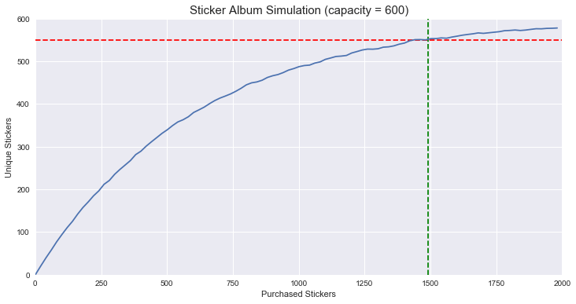

```python
xmin, xmax = 0 , 2000
ymin, ymax = 0 , 600

plt.figure(figsize = (12,6))
#plt.plot(range(1, 2001, 1),y)
plt.plot(range(1, 2001, 20),y2)
plt.axis((xmin,xmax,ymin,ymax))
plt.hlines(550, xmin, xmax, color = "red", linestyle = "--")
plt.vlines(1491, ymin, ymax, color = "green", linestyle = "--")
plt.xlabel("Purchased Stickers")
plt.ylabel("Unique Stickers")
plt.title("Sticker Album Simulation (capacity = 600)", fontsize = 15)
plt.show()
```

```python
def optimize(album_capacity = 600, random_start = 800, sims = 10, seed = 123,
             target = 550, learning_rate = 7, epochs = 20, tolerance = 0.5):

    for _ in range(epochs):
        result = StickerAlbum(album_capacity = album_capacity, purchased_stickers = int(random_start), sims = sims, seed = seed)
        delta = (result-target)
        print(random_start, result)
        if abs(delta)<tolerance:
            break
        else:
            random_start -= round(learning_rate * delta)
    return random_start, result
```

### Fine Tuning Default Parameters

```python
optimize(album_capacity=600, target = 300, random_start= 800, learning_rate = 2) #does not work for smaller targets
```

```
800 444.7
511 343.9
423 301.4
420 300.4
```

```
(420, 300.4)
```

```python
optimize(album_capacity=600, target = 595, random_start= 800, learning_rate = 10, epochs = 20) #flat part of the curve
```

```
800 444.7
2303 588.8
2365 590.2
2413 590.7
2456 591.2
2494 591.5
2529 591.9
2560 592.3
2587 592.6
2611 592.5
2636 593.6
2650 594.1
2659 594.2
2667 594.3
2674 594.4
2680 594.4
2686 594.6
```

```
(2686, 594.6)
```

```python
optimize(album_capacity=600, target = 595, random_start= 800, learning_rate = 7, epochs = 50) #flat part of the curve
```

```
800 444.7
1852 573.1
2005 579.9
2111 582.8
2196 585.8
2260 587.7
2311 589.2
2352 589.3
2392 591.0
2420 590.8
2449 591.1
2476 591.4
2501 591.8
2523 591.8
2545 592.2
2565 592.1
2585 592.7
2601 592.2
2621 592.6
2638 593.8
2646 593.7
2655 594.0
2662 594.1
2668 594.2
2674 594.4
2678 594.5
2682 594.5
2686 594.6
```

```
(2686, 594.6)
```

```python
optimize(album_capacity=600, target = 595, random_start= 3000, learning_rate= 10) #random start at very flat part
```

```
3000 596.8
2982 597.0
2962 597.3
2939 596.5
2924 596.2
2912 596.3
2899 596.4
2885 595.9
2876 595.8
2868 595.9
2859 596.1
2848 595.8
2840 595.5
2835 595.2
```

```
(2835, 595.2)
```

```python
def optimize(album_capacity = 600, random_start_frac = 0.8, sims = 10, seed = 123,
             target = 550, learning_rate = 4, epochs = 100, tolerance = 0.5):

    random_start = round(album_capacity * random_start_frac)

    for _ in range(epochs):
        result = StickerAlbum(album_capacity = album_capacity, purchased_stickers = int(random_start), sims = sims, seed = seed)
        delta = (result-target)
        print(random_start, result)
        if abs(delta)<tolerance:
            break
        else:
            random_start -= round(learning_rate * delta)
    return random_start, result
```

```python
optimize(target = 550, learning_rate= 4)
```

```
480 330.2
1359 535.8
1416 545.6
1434 549.3
1437 550.2
```

```
(1437, 550.2)
```

```python
optimize(album_capacity= 600, target = 599, learning_rate = 10) #very flat point of the curve
```

```
480 330.2
3168 597.5
3183 597.5
3198 597.4
3214 597.6
3228 597.9
3239 598.0
3249 598.1
3258 598.4
3264 598.5
3269 598.5
3274 598.5
3279 598.6
```

```
(3279, 598.6)
```

```python
optimize(album_capacity= 600, target = 550, learning_rate = 4) #moderate point of the curve
```

```
480 330.2
1359 535.8
1416 545.6
1434 549.3
1437 550.2
```

```
(1437, 550.2)
```

```python
optimize(album_capacity=600, target = 10, learning_rate = 1) #steep point of the curve
```

```
480 330.2
160 141.4
29 28.6
10 10.0
```

```
(10, 10.0)
```

```python
optimize(album_capacity=20, target = 19, tolerance = 0.2, learning_rate = 4) #small album, flat point
```

```
16 11.1
48 18.4
50 18.6
52 18.6
54 19.0
```

```
(54, 19.0)
```

```python
optimize(album_capacity=20, target = 15, tolerance = 0.2, learning_rate = 4) # small album, moderate point
```

```
16 11.1
32 16.0
28 15.3
27 14.8
```

```
(27, 14.8)
```

```python
optimize(album_capacity=20, target = 3, tolerance = 0.2, learning_rate= 1, sims = 10000) #small album, steep point
```

```
16 11.1963
8 6.7296
4 3.7115
3 2.8589
```

```
(3, 2.8589)
```

```python
optimize(album_capacity=2000, target = 1990, learning_rate=10) #large album, flat point
```

```
1600 1101.4
10486 1989.2
10494 1989.3
10501 1989.0
10511 1989.0
10521 1989.2
10529 1989.0
10539 1989.1
10548 1989.0
10558 1989.0
10568 1989.3
10575 1989.8
```

```
(10575, 1989.8)
```

```python
optimize(album_capacity=2000, target = 1800, learning_rate= 4) #large album, moderate point
```

```
1600 1101.4
4394 1776.7
4487 1785.7
4544 1790.6
4582 1798.0
4590 1798.1
4598 1800.2
```

```
(4598, 1800.2)
```

```python
optimize(album_capacity=2000, target = 100, learning_rate= 1) #large album, steep point
```

```
1600 1101.4
599 512.9
186 178.1
108 106.0
102 99.4
103 100.2
```

```
(103, 100.2)
```

```python
def optimize(album_capacity = 600, random_start_frac = 0.8, sims = 10, seed = 123,
             target = 550, learning_rate = 4, epochs = 100, tolerance = 0.5):

    random_start = round(album_capacity * random_start_frac)

    for _ in range(epochs):
        result = StickerAlbum(album_capacity = album_capacity, purchased_stickers = int(random_start), sims = sims, seed = seed)
        delta = (result-target)
        #print(random_start, result)
        if abs(delta)<tolerance:
            break
        else:
            random_start -= round(learning_rate * delta)
    return random_start, result
```

```python
optimize(album_capacity= 376, target= 326, sims = 1000, tolerance = 0.1)
```

```
(756, 325.96)
```

# See you in the Numpy Section!!!